# Chicago Ridehail Open Data: Drivers

# Data source

Chicago publishes three data sets about Transportation Network Providers operations in the city. This notebook uses the [Drivers](https://data.cityofchicago.org/Transportation/Transportation-Network-Providers-Drivers/j6wf-834c) data set. All three are updated monthly. I download the Drivers set as a CSV file; the Trips data set is too big for that, and (in other notebooks) I query it from the notebook.

After download, remove some obvious gaps and errors (like drivers with a start date before 2011, or drivers with a start date after the month reported).

In this notebook, “drivers” = “active drivers”, which is to say drivers with a number of trips > 0 in a given month.

# Trips per month

Start with an overview of trip volume over time.

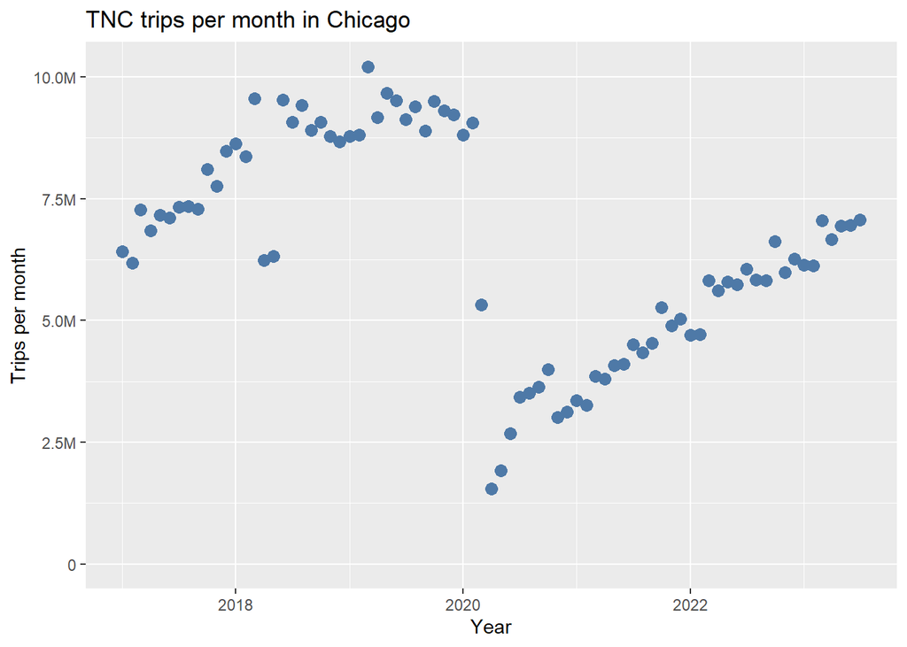

**Discussion**

There are three periods:

For comparison with other cities, 9M trips per month is equivalent to: - 300,000 per day, or - 12000 per hour, or - 200 per minute.

# Driver population

The trend for active drivers parallels that for trips.

Regarding the outliers in Q2 2018, there is a note on the City of Chicago web site:

> [S]ome vehicle records for Q2 2018 (April-June) were reported for the quarter as a whole, rather than for individual months. For purposes of this dataset, those records have been assigned to 2018-06 (June). Therefore, some caution in interpreting this month and the quarter as a whole is advised.

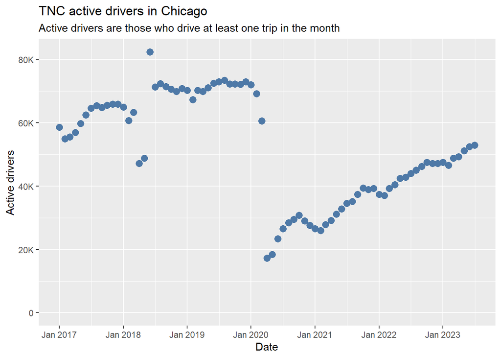

**Discussion**

The basic pattern is the same as that for trips. The Covid plummet is a bit less complete, although still dramatic.

## Drivers, by hours driven

There is no one Uber driver. To understand how Uber operates, it helps to know what the range of driver participation is. Some drive only occasionally, some drive full time.

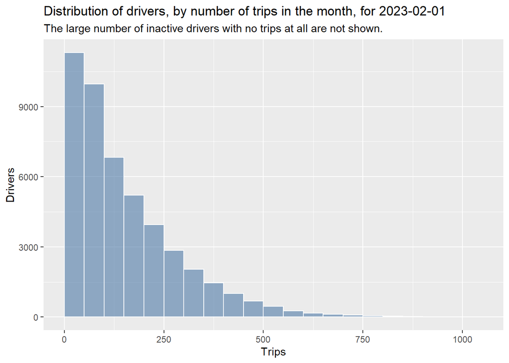

## Categorizing drivers

The Chicago data set does not provide driver times on the platform. The nearest we get is the number of trips in the month.

Using an average of 20 minutes per trip (from the Trips data set) and a utilization rate of 66% (a generous estimate from Fehr & Peers) gives two trips per hour. A 30 hour week translates into 60 trips, which is about 250 trips per month.

### Seattle classification

First, The Seattle classification of Hyman et al to map that onto the Chicago data. The categories are:

| Category | Trips | Estimated hours / week |
| --- | --- | --- |
| 1 | < 40 | < 5 |
| 2 | 41 – 160 | 5 – 20 |
| 3 | 161 – 240 | 20 – 30 |
| 4 | 241 – 320 | 30 – 40 |
| 5 | > 320 | > 40 |

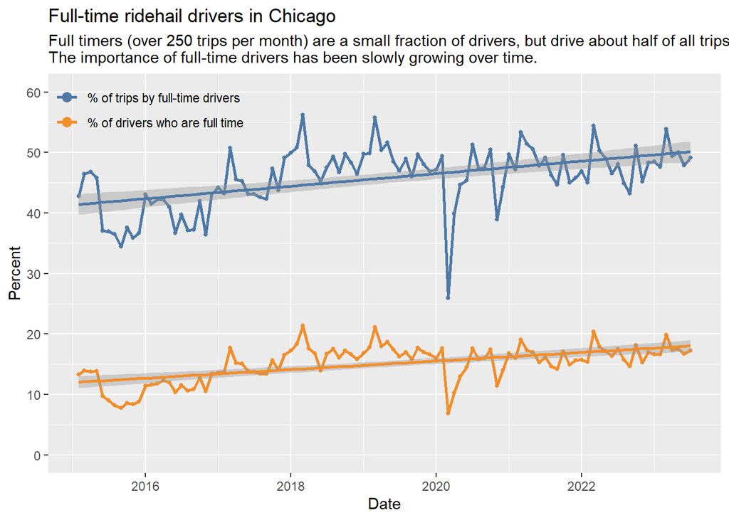

Here are the values for the most recent month:

```r
tb %>% filter(month_reported==max(month_reported), driver_category=="Full time")
```

```
## # A tibble: 2 × 6
##   month_reported driver_category drivers   trips measure        value
##   <date>         <chr>             <int>   <int> <fct>          <dbl>
## 1 2023-07-01     Full time          9140 3470503 driver_percent  17.3
## 2 2023-07-01     Full time          9140 3470503 trip_percent    49.1
```

**Discussion**

Full-timers and part-timers are both essential to Uber and Lyft’s ability to deliver the volume of trips they handle. But these two groups do not always share the same interests.

## Mean and median number of trips per driver

Although there is no “one type of Uber driver”, averages may still be useful to track trends.

The average number of trips per driver increased during 2017 (as measured both by median and mean): the number of drivers stayed roughly the same while the number of trips continued to grow. In 2018 and 2019 there was a roughly steady state, with an average of about 125 trips per month (about 16 hours per week), a number that has been restored during 2022.

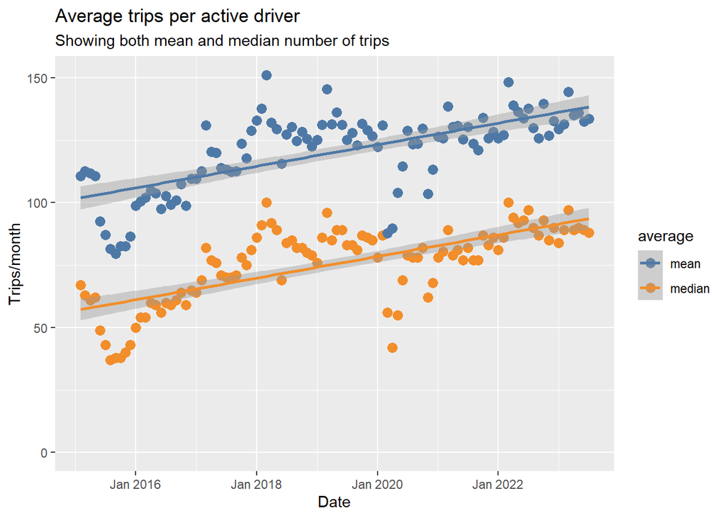

# Driver longevity and churn

## Driver population by longevity

The first chart takes a specific month and shows the distribution of drivers, by longevity, on the platform in that month.

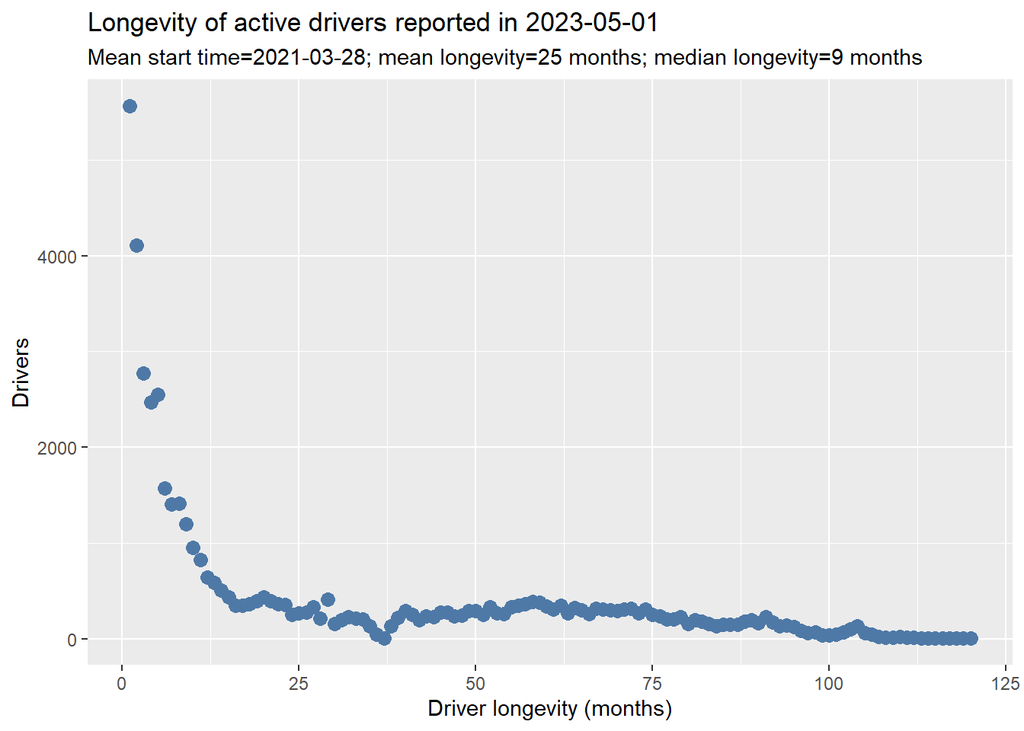

It can be easier to interpret this if we lump drivers into new or long-term workers, based on whether they have been on the platform for more or less than a year.

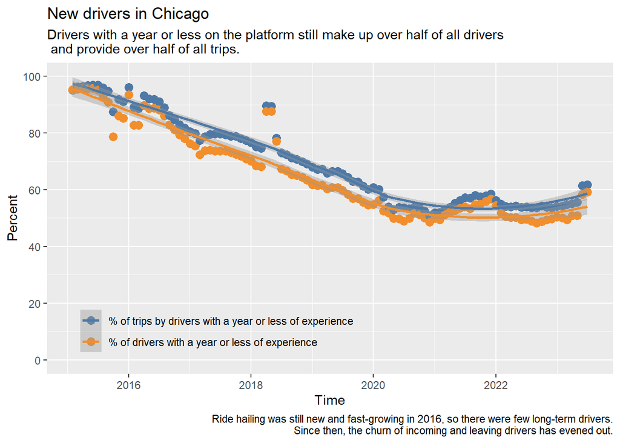

Both mean and median longevity (below) confirm the observation that the driver population has been on the platform for longer, over time, albeit with a major Covid interruption.

The Chicago data does not allow us to see whether drivers have gaps in their work: we just have a first month they are recognized and the reporting month.

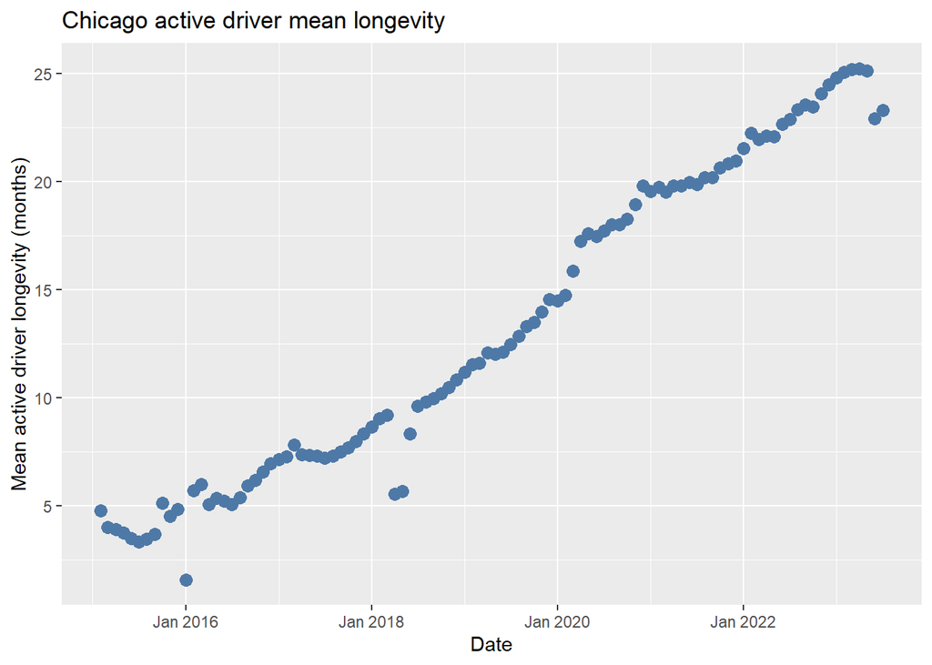

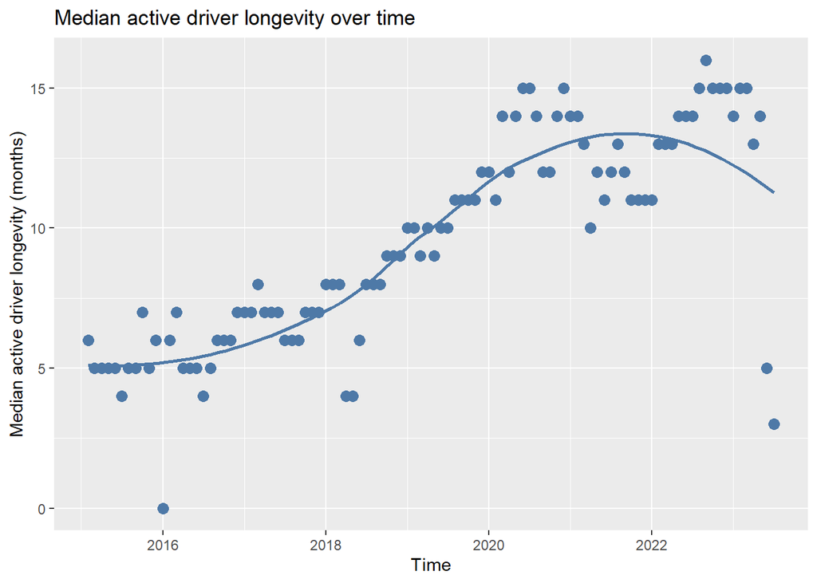

## Driver churn

The next chart takes a given starting month, and looks at how many drivers are left over time.

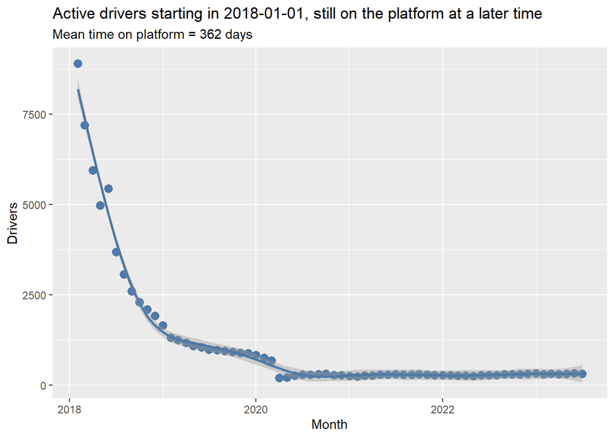

Now see if we can say “how many quit over their first year”.

**Note: I do not trust this graph**

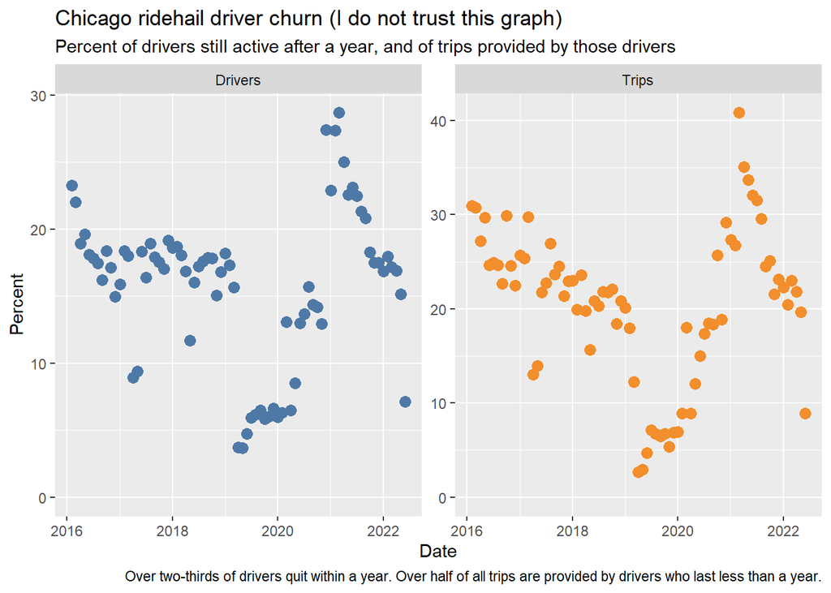

## Trip distribution

In a given month, how many trips are given by drivers with a residency of X months?

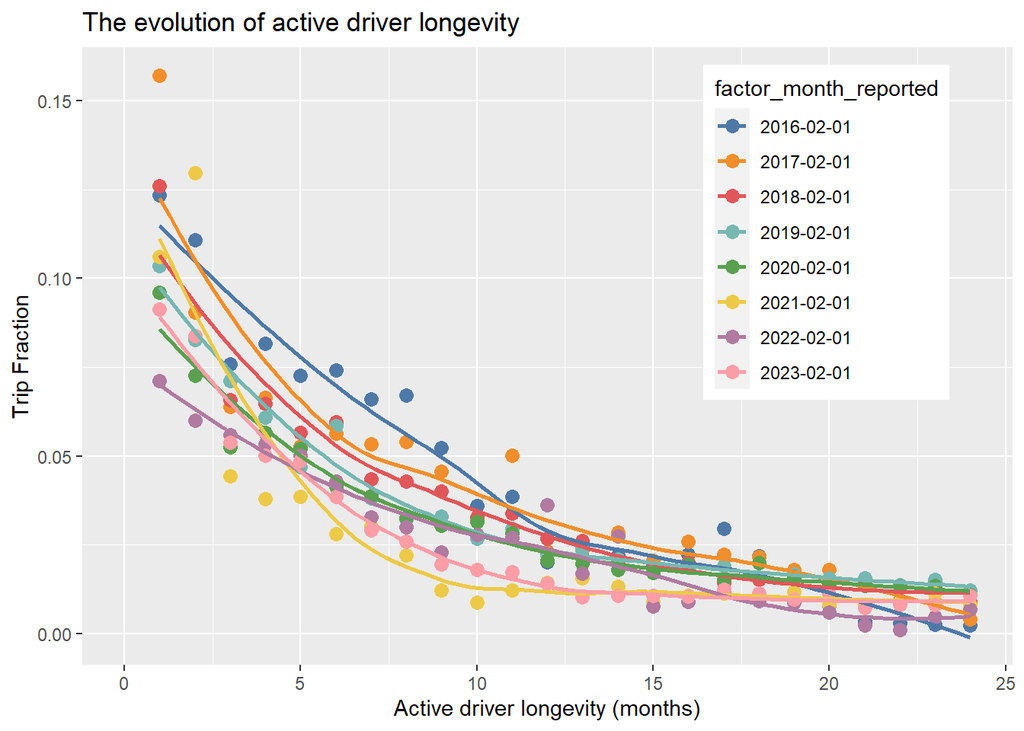

Now do this over all months, not just an individual month, summing over the longevity of the driver.

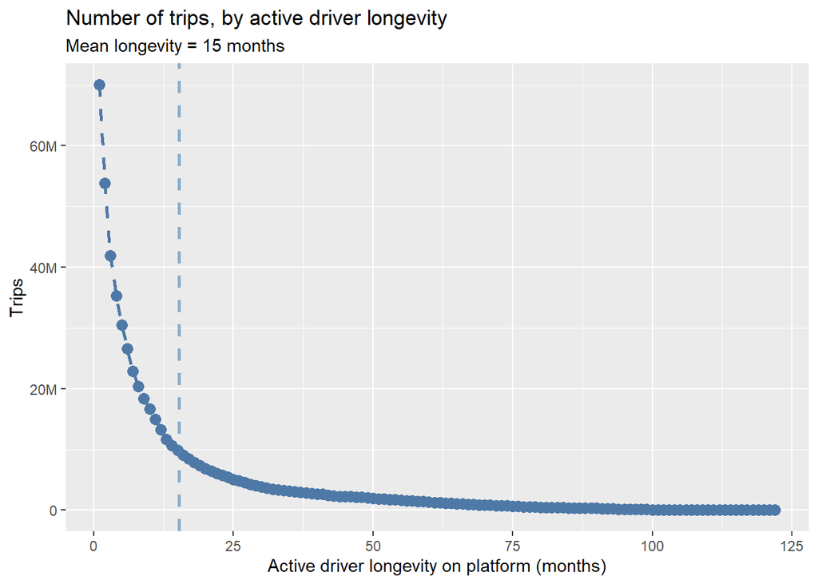

## New starts and quits, by month

First let’s do starts, as that is easy.

The data point for Jan 2016 was a BIG outlier, and is excluded.

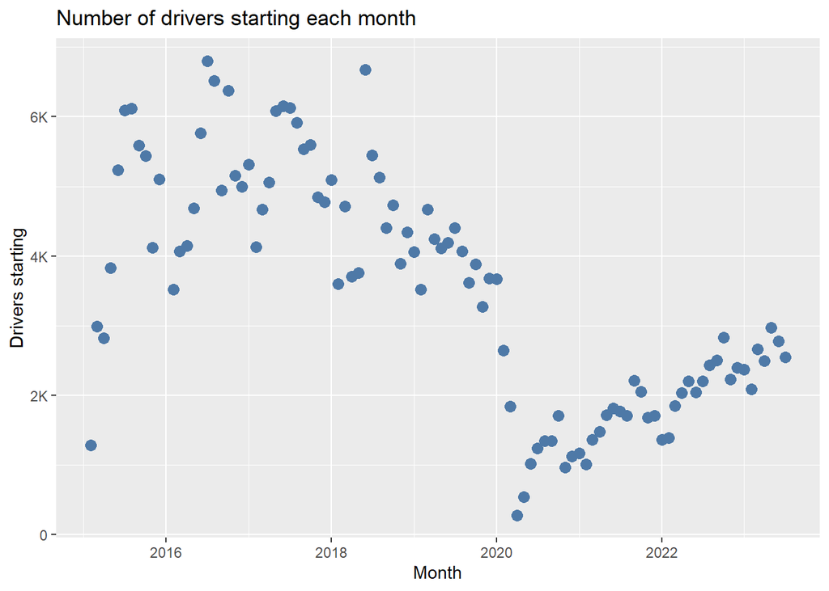

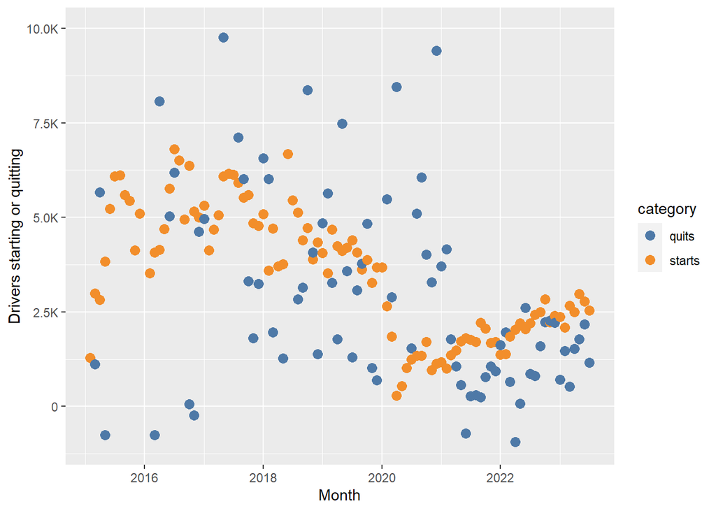